# Türkiye’de Son 20 Yılda Gerçekleşen Depremler

Ayşenur Gençdoğmuş, Sevda Hamzaçebi

Bu projede, son 20 yılda 4 ve üzeri büyüklükte Türkiye’de gerçekleşen depremleri temel bilgiler ekseninde görselleştirmeye çalıştık.

**Deprem Nedir?**

Yerkabuğu içindeki kırılmalar nedeniyle ani olarak ortaya çıkan titreşimlerin dalgalar halinde yayılarak geçtikleri ortamları ve yer yüzeyini sarsma olayıdır.

**Türkiye Deprem Kuşağı**

Türkiye dünyanın aktif deprem kuşaklarından biri olan Alp-Himalaya deprem kuşağı üzerinde yer alır. Ülkemizin yüz ölçümünün % 42’si birinci derece deprem kuşağındadır.

1- Kuzey Anadolu Deprem Kuşağı

Türkiye’nin kuzey kesiminde doğu-batı doğrultusunda uzanan kuzey Anadolu deprem kuşağı yaklaşık 1500 km uzunluğa sahiptir. Marmara Bölgesi’nde; Saros Körfezinden başlar, Doğu Anadolu Bölgesi’ndeki Aras Vadisi’ne kadar uzanır.

2- Güneydoğu Anadolu Deprem Kuşağı:

İskenderun Körfezi’nden Van’ın doğusuna kadar bir yay çizerek uzanır. Hatay, Kahramanmaraş, Adıyaman, Malatya, Elazığ, Bitlis ve Van bu kuşaktır.

3- Batı Anadolu Deprem Kuşağı

Ege Bölgesi’ndeki Bakırçay, Gediz, Küçük ve Büyük Menderes çöküntü ovaları boyunca uzanan bazı diri fay hatları bulunmaktadır. Bu deprem kuşağı; Ayvalık, Dikili, İzmir, Aydın, Denizli, Isparta ve Akşehir’in içine alır.

**İlgili Terimler**

Büyüklük

Kırılan yüzeyin büyüklüğünü ve dolayısıyla ortaya çıkan enerjinin düzeyini belirten bir ölçüdür.

Derinlik

Depremde enerjinin açığa çıktığı noktanın yeryüzünden en kısa uzaklık

Şiddet

Depremin yer yüzeyindeki etkileri depremin şiddeti olarak tanımlanır. Şiddetin ölçüsü, insanların deprem sırasında uykudan uyanmaları, mobilyaların hareket etmesi, bacaların yıkılması ve toplam hasar gibi çeşitli kıstaslar göz önüne alınarak yapılır.

Öncelikle http://deprem.afad.gov.tr/ddakatalogu adresinden söz konusu aralıktaki veriyi indirip görselleştirme için uygun hale getirdik.

```r
#gerekli kütüphaneler
library(tidyverse)
library(lubridate)
library(sp)


#veriyi okuyalım ve kullanacağımız sütunları alalım
deprem<-read.csv("deprem20yil.csv",encoding = "UTF-8")
glimpse(deprem)
deprem<-deprem[,3:9]
```

Ülke bilgisi Türkiye’den farklı ve eksik örnekler bulunuyor, farklı olanları süzelim.

```r
deprem<-filter(deprem,Ulke=="Türkiye" | Ulke=="-") %>% mutate(Ulke=factor(Ulke),Sehir=factor(Sehir)) %>% filter(Enlem<=42 & Enlem>=36 & Boylam>=26 & Boylam<=45)
```

Harita üzerinde baktığımızda sınırlara yakın ve denizlerdeki depremlerin de veride geldiğini görüyoruz. Harita için https://github.com/sercandogan/turkeymap/blob/master/howtomake.Rmd adresinde anlatılan yöntemi kullandık.

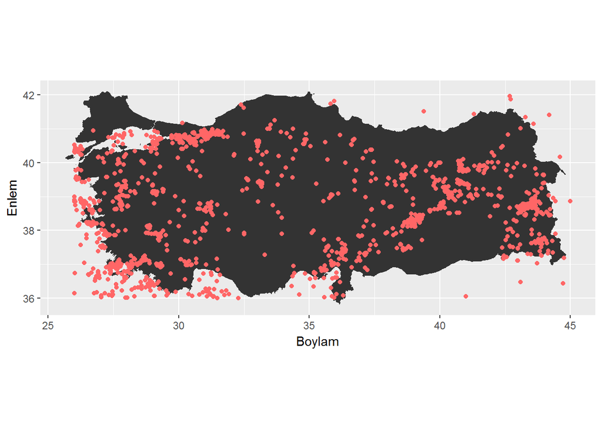

```r
#Türkiye haritası
TR_map<-readRDS("TUR_adm1")
harita<-fortify(TR_map)

ggplot() + geom_polygon(data = harita, aes(x=long, y = lat, group = group)) +
  coord_fixed(1.3)+
  geom_point(data = deprem,aes(x=Boylam,y=Enlem),col="#FF6666") + labs(x="Boylam",y="Enlem")
```

Yıl ve ay bazında deprem sayılarını incelemek için yeni sütunlar oluşturalım.

```r
deprem <- deprem %>% mutate(yil=year(Tarih_UTC),ay=month(Tarih_UTC))
```

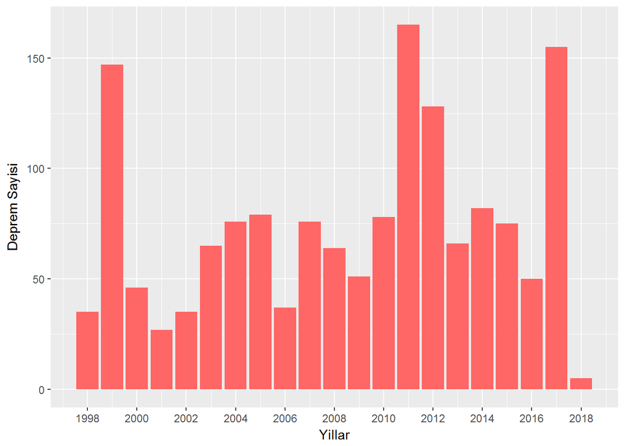

```r
#Yıllara göre toplam deprem sayıları
deprem %>% group_by(yil) %>% summarise(Toplam=n()) %>%
  ggplot(aes(x = yil, y = Toplam)) + geom_bar(stat="identity",fill="#FF6666") + labs(x = "Yıllar", y = "Deprem Sayısı") + scale_x_continuous(breaks=seq(1998,2018,by=2))
```

Büyüklük seviyelerine göre harita üzerinde baktığımızda son 20 yıldaki yıkıcı deprem bölgelerine erişiyoruz. En fazla depremin olduğu yıllar, en büyük hasarlı depremler ve sonrasındaki artçı sarsıntılar olarak gözlemlenebilir.

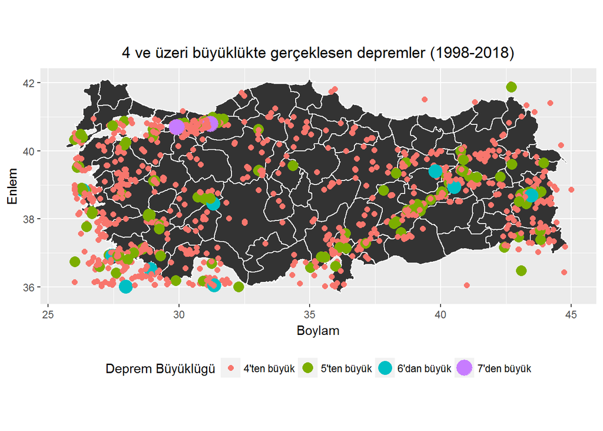

```r
#Büyüklük seviyeleri ekleyelim
deprem<-mutate(deprem,seviye=ifelse(Buyukluk>=7,"7'den büyük",ifelse(Buyukluk>=6,"6'dan büyük",ifelse(Buyukluk>=5,"5'ten büyük","4'ten büyük"))))

#Harita üzerinde görelim
ggplot() + geom_polygon(data = harita, aes(x=long, y = lat, group = group),color="white") +
  coord_fixed(1.3)+
  geom_point(data = deprem,aes(x=Boylam,y=Enlem,col=seviye,size=seviye)) + theme(legend.position = "bottom",plot.title = element_text(hjust = 0.5)) +
  labs(color="Deprem Büyüklüğü",size="Deprem Büyüklüğü",x="Boylam",y="Enlem",title="4 ve üzeri büyüklükte gerçekleşen depremler (1998-2018)")
```

Yıl bazında ise en büyük depremler şu şekilde gözlenir:

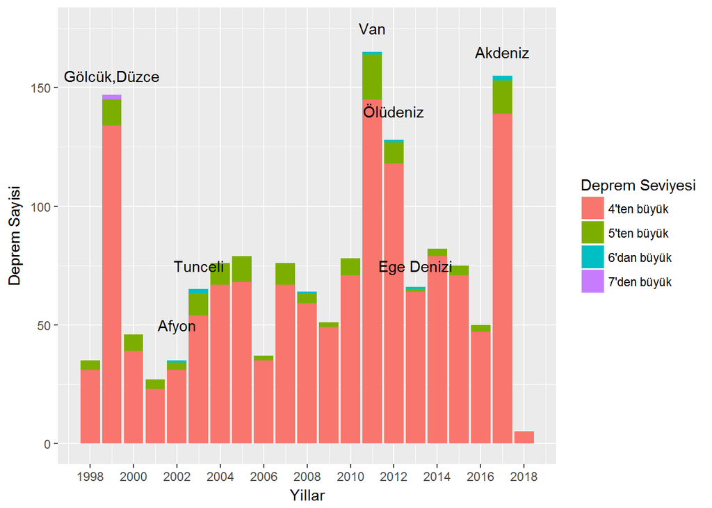

```r
deprem_seviyeleri<-deprem %>% group_by(yil,seviye) %>% summarise(Toplam=n()) %>% ungroup()

seviye_label<- unique(deprem_seviyeleri$seviye)

ggplot(deprem_seviyeleri, aes(x=yil, y=Toplam,group=ordered(seviye,levels=rev(seviye_label)))) +
  geom_col(aes(fill =  seviye)) + labs(x = "Yıllar", y = "Deprem Sayısı",fill="Deprem Seviyesi") + scale_x_continuous(breaks=seq(1998,2018,by=2))+ annotate("text",x=1999,y=155,label="Gölcük,Düzce") + annotate("text",x=2002,y=50,label="Afyon") + annotate("text",x=2003,y=75,label="Tunceli") + annotate("text",x=2011,y=175,label="Van") + annotate("text",x=2017,y=165,label="Akdeniz") + annotate("text",x=2012,y=140,label="Ölüdeniz") + annotate("text",x=2013,y=75,label="Ege Denizi")
```

Ay bazında en büyük depremlerden sonra yaşanan artçı sarsıntılar sapma oluşturmaktadır.

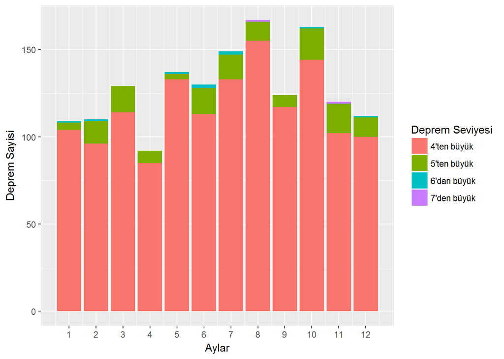

```r
#Depremleri büyüklüğe göre ay bazında görelim
deprem %>% group_by(ay,seviye) %>% summarise(Toplam=n()) %>% ungroup() %>% ggplot(aes(x=ay, y=Toplam,group=ordered(seviye,levels=rev(seviye_label)))) +
  geom_col(aes(fill =  seviye)) + scale_x_continuous(breaks=seq(1,12,by=1)) +labs(x = "Aylar", y = "Deprem Sayısı",fill="Deprem Seviyesi")
```

Saat bazında baktığımıza, depremlerin günün belirgin bir vaktinde gerçekleşmediğini gözlemliyoruz.

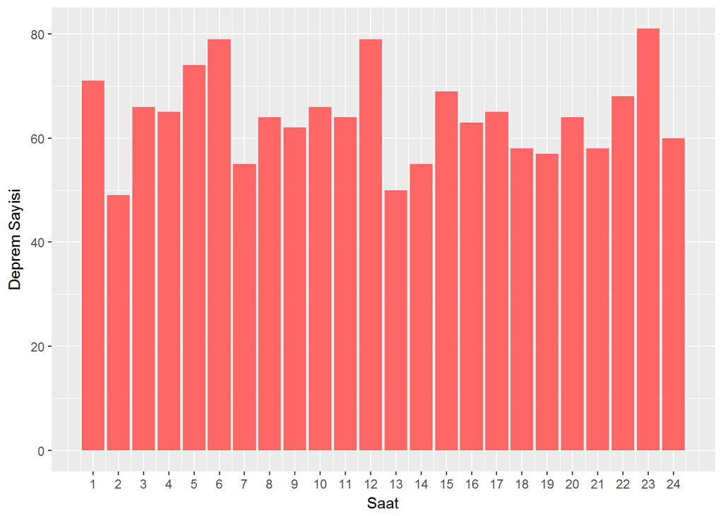

```r
#Depremleri gerçekleştiği saat bazında görelim
deprem %>% mutate(saat=hour(Tarih_UTC)+1) %>% group_by(saat) %>% summarise(Toplam=n()) %>% ungroup() %>% ggplot(aes(x=saat, y=Toplam)) +
  geom_col(fill="#FF6666") + scale_x_continuous(breaks=seq(1,24,by=1)) +labs(x = "Saat", y = "Deprem Sayısı")
```

En yıkıcı depremlerin büyüklük olarak fazla ve yüzeye yakın gerçekleştiği bilinmektedir. Derinlik ve büyüklük arasındaki ilişkiye baktığımızda bir ilişkisellik görmüyoruz. Son 20 yıldaki depremlerin genellikle derinliği 40 metreden az olduğunu söyleyebiliriz.

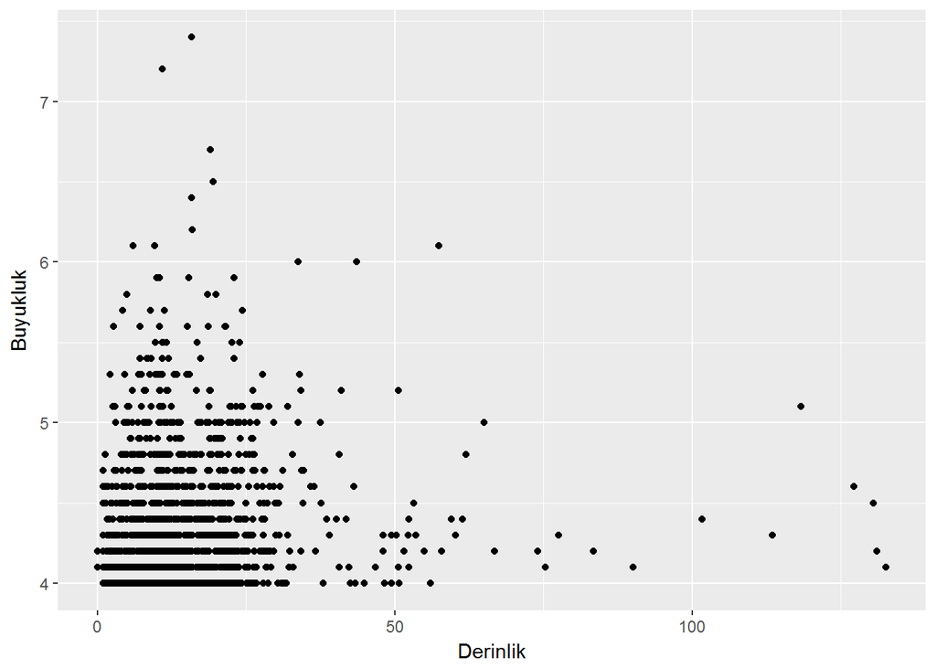

```r
deprem %>% ggplot(aes(x=Derinlik,y=Buyukluk)) + geom_point()
```

Deprem kuşağında yer aldığımızı ve deprem gerçeği ile yaşamak durumunda olduğumuzu tekrar hatırlayarak, asıl önemli olanın güvenli yapılar ile kapsamlı afet yönetimi olduğu notunu buraya düşelim. Gelecekte Gölcük, Düzce, Van depremlerinde yaşadığımız felaketleri bir daha yaşamamak umuduyla…

*Mustafa Gökçe Baydoğan & Berk Orbay’a ve Akademik Bilişim kapsamında bu kursların düzenlenmesinde emeği geçenlere çok teşekkür ederiz.

Kaynaklar:

http://deprem.afad.gov.tr/

http://www.koeri.boun.edu.tr